### Description

Calculate and plot r and Cohen’s d/Hedges’ g effect size and its confidence intervals.

### Usage

```r
effsize_plot(x, g, method = 'r', paired = F,
             color = 'black', size = 2,
             width = .05,
             line.col = 'grey', lwd = 1, lty = 2,
             ggtheme = theme_minimal(),
             par_r = list(conf = .95, type = 'perc', R = 1000),
             par_d = list(pooled = T, hedges.correction = F, conf.level = .95),
             plot = T, show = F)
```

### Arguments

`x`, `g` dataframe and vector with numerical and factor variables, respectively.

`method` specify what effect size to compute: Wilcoxon r (`'r'`) or Cohen’s d (`'d'`). For Hedges’ g, set `hedges.correction` to `TRUE` (see `par_d`).

`paired` logical. Wether the samples are paired.

`color`, `size` character or hexa specifying the errorbar and point colors, and size of points, respectively.

`width` width of errorbar brackets.

`line.col`, `lwd`, `lty` color, width and type of the zero-crossing line, respectively.

`ggtheme` a ggplot2 theme function.

`par_d` list of parameters to be passed to `cohen.d` function. Specify as `list(pooled, hedges.correction, conf.level)`, where `pooled` is a logical indicating whether should be used the pooled standard deviation (`TRUE`, default) or the whole sample standard deviation (`FALSE`), `hedges.correction` is a logical indicating if Hedges correction should be applied (`TRUE`) or not (`FALSE`, default) and `conf.level` is the level of confidence inteval.

`plot` logical indicating whether to plot (`TRUE`, default) or not (`FALSE`)

`show` logical indicating whether to print the estimate, p-value, effect size and its confidence intervals (`TRUE`) or not (`FALSE`, default).

### Details

The packages `rcompanion` (Mangiafico 2020) and `effsize` (Torchiano 2020) are required to calculate r and d/g effect size, respectively.

For more details about how each effect size is calculated, read the documentation of [`rcompanion`](https://cran.r-project.org/web/packages/rcompanion/rcompanion.pdf) and [`effsize`](https://cran.r-project.org/web/packages/effsize/effsize.pdf).

### Value

A list comprised of:

`es_plot` the plot output.

`metrics` a `data.frame` with variable names, statistic (t or W/V), p-value, effect size (r or d/g) and lower and upper limits of confidence interval.

### Examples

Generating dataset

```r
x <- factor(rep(c('A','B'), each = 50))

y1 <- abs(rnorm(100, mean = 8.4, sd = 2)) %>% round(.,0)
y1[51:100] <- abs(rnorm(50, 10, 4)) %>% round(.,0)

y2 <- abs(rnorm(100, 25, 5)) %>% round(.,0)
y2[51:100] <- abs(rnorm(50, 23.3, 4)) %>% round(.,0)

y3 <- abs(rnorm(100, 8.5, 4)) %>% round(.,0)
y3[51:100] <- abs(rnorm(50, 11.2, 5.5)) %>% round(.,0)

df <- data.frame(x,y1,y2,y3)
```

Loading the function

```r
source('https://github.com/geovanjr/stats/raw/master/effsize_plot.R')
```

Calculating r effect size

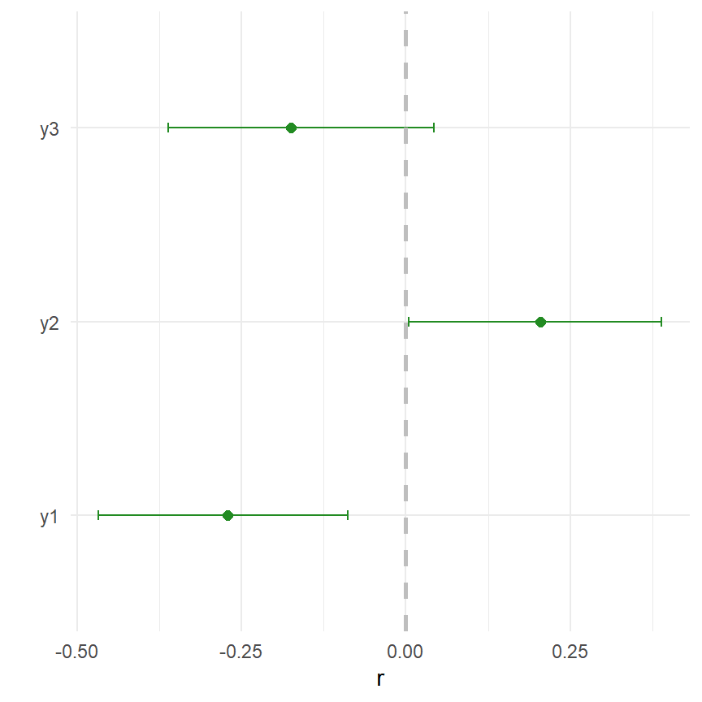

```
##   variable      W      p      r    lower   upper
## 1       y1  859.5 0.0067 -0.271 -0.46700 -0.0882
## 2       y2 1546.0 0.0409  0.205  0.00481  0.3890
## 3       y3  999.0 0.0831 -0.174 -0.36100  0.0430
```

```r
effsize_plot(df[,2:4], df[,1], method = 'r', paired = F, plot = T, show = T,
             color = 'forestgreen',
             par_r = list(R = 500))
```

Calculating d effect size

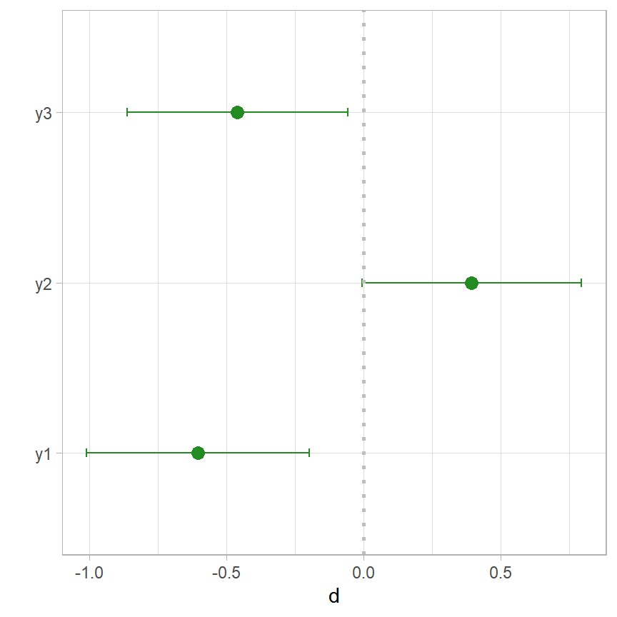

```
##   variable         t      p          d        lower       upper
## 1       y1 -3.019994 0.0035 -0.6039988 -1.009840950 -0.19815667
## 2       y2  1.972555 0.0514  0.3945111 -0.006224558  0.79524674
## 3       y3 -2.297717 0.0238 -0.4595433 -0.861641189 -0.05744545
```

```r
effsize_plot(df[,2:4], df[,1], method = 'd', paired = F, plot = T, show = T,
             color = 'forestgreen', size = 3, lty = 3, ggtheme = theme_light())
```

Calculating g effect size

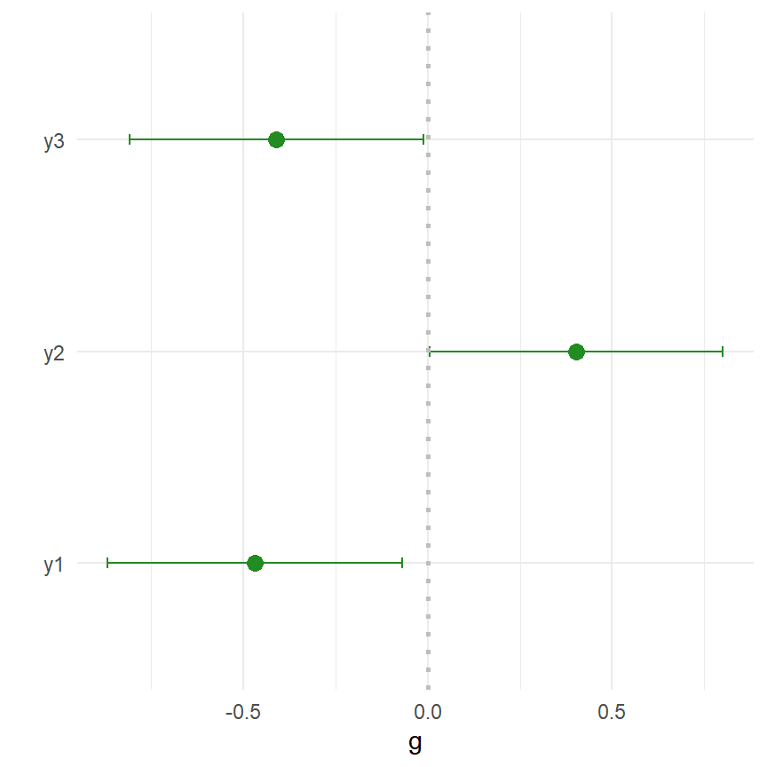

```
##   variable         t      p          g        lower       upper
## 1       y1 -3.019994 0.0035 -0.4689179 -0.868142052 -0.06969377
## 2       y2  1.972555 0.0514  0.4028026  0.004980506  0.80062469
## 3       y3 -2.297717 0.0238 -0.4102974 -0.808267973 -0.01232683
```

```r
effsize_plot(df[,2:4], df[,1], method = 'd', paired = F, plot = T, show = T,
             color = 'forestgreen', size = 3, lty = 3,
             par_d = list(hedges.correction = TRUE))
```

Changing `es_plot` aesthetics

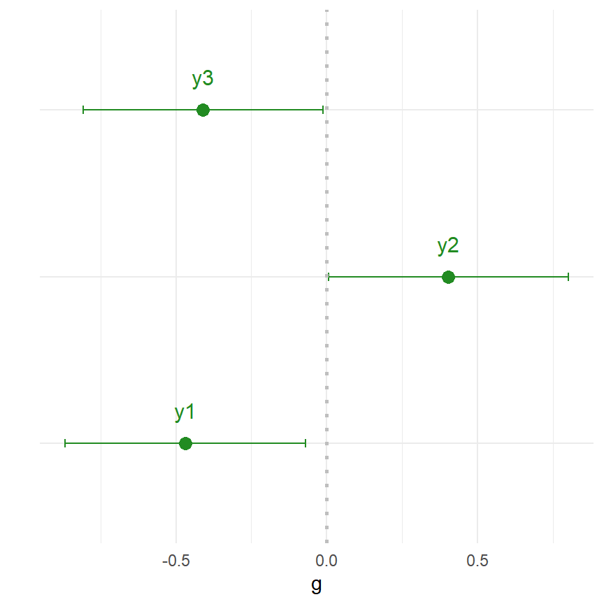

```r
es <- effsize_plot(df[,2:4], df[,1], method = 'd', paired = F, plot = F, show = F,
             color = 'forestgreen', size = 3, lty = 3,
             par_d = list(hedges.correction = TRUE))

es$es_plot +
  theme(axis.text.y = element_blank()) +
  annotate('text', 1+.2, es$metrics[1,4],
           label = paste0(es$metrics[1,1]),
           size = 4, color = 'forestgreen') +
  annotate('text', 2+.2, es$metrics[2,4],
           label = paste0(es$metrics[2,1]),
           size = 4, color = 'forestgreen') +
  annotate('text', 3+.2, es$metrics[3,4],
           label = paste0(es$metrics[3,1]),
           size = 4, color = 'forestgreen')
```

Getting `metrics`

```r
es$metrics
```

| variable | t | p | g | lower | upper |
| --- | --- | --- | --- | --- | --- |
| y1 | -3.019994 | 0.0035 | -0.4689179 | -0.8681421 | -0.0696938 |
| y2 | 1.972555 | 0.0514 | 0.4028026 | 0.0049805 | 0.8006247 |
| y3 | -2.297717 | 0.0238 | -0.4102974 | -0.8082680 | -0.0123268 |

### References

Mangiafico, Salvatore. 2020. *Rcompanion: Functions to Support Extension Education Program Evaluation*. https://CRAN.R-project.org/package=rcompanion.

Torchiano, Marco. 2020. *Effsize: Efficient Effect Size Computation*. https://CRAN.R-project.org/package=effsize.